# Lab 2 - `ggplot2` continued

# Practice Problems

**Question 18:** The code below will load a data set containing 970 Hollywood films released between 2007 and 2011, then reduce these data to only include variables that could be known prior to a film’s opening weekend. The data are then simplified further to only include the four largest studios (Warner Bros, Fox, Paramount, and Universal) in the three most common genres (action, comedy, drama). You will use the resulting data for this question.

```r
movies <- read.csv("https://collinn.github.io/data/hollywood.csv")
movies <- filter(movies, Genre %in% c("Action", "Comedy", "Drama"),
                 LeadStudio %in% c("Warner Bros", "Fox", "Paramount", "Universal")) %>%
  select("Movie", "LeadStudio", "Story", "Genre","Budget",
         "TheatersOpenWeek","Year","OpeningWeekend")
```

With your group, create 2-3 *publication ready graphics* that effectively differentiate movies with high revenue on opening weekend from those with low revenue on opening weekend (the variable `OpeningWeekend` records this revenue in millions of US dollars). Write a few sentences comparing the plots you created and any trends that you found.

**Question 19:** The data frame `diamonds`, like `mpg`, is included in the `ggplot2` package. This data records the attributes of several thousand diamonds sold by a wholesale online retailer. Your goal is to recreate the graph shown below as closely as possible. A few hints:

- Pay attention to scales, theme, and labels
- Find what transformations are available for continuous x axis
- The argument `alpha = 0.3` is used in one of the layers to give each point 30% opacity
- Default colors are used

```r
library(ggplot2)
data("diamonds")
```

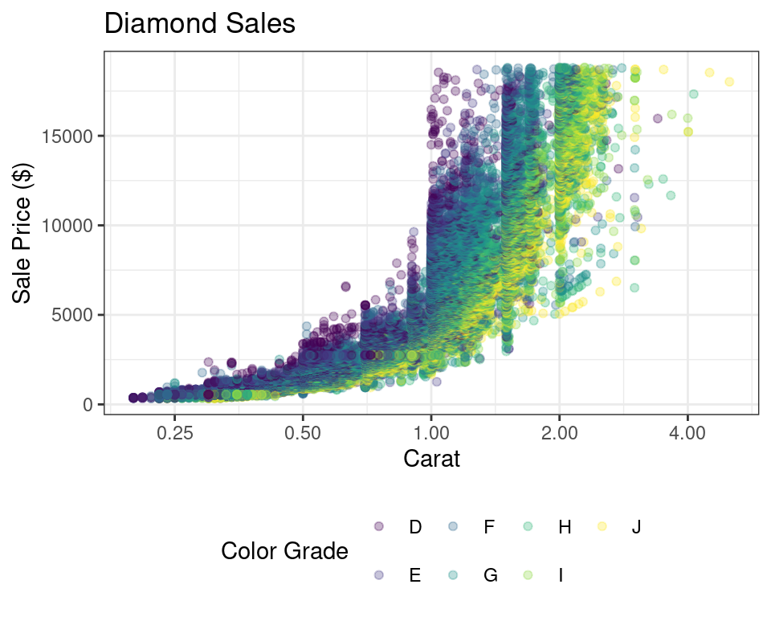

```r
## Generating code
ggplot(diamonds, aes(carat,  price, color = color)) +
  geom_point(alpha = 0.3) + theme_bw() + scale_x_continuous(trans = "log2") +
  labs(x = "Carat", y = "Sale Price ($)", color = "Color Grade", title = "Diamond Sales") + theme(legend.position = "bottom")
```